# 2 užduotis

Aina Petronytė

2017 m sausis 20 d

## 2 užduotis

Tarkime, $X_1$ ir $X_2$ yra nepriklausomi, $X_1 \sim N(3, 2)$, $X_2 \sim N(-1, 3)$ ir $X = X_1 + X_2$. Kadangi $X$ yra normaliųjų atsitiktinių dydžių suma, tai jo vidurkis yra tų atsitiktinių dydžių vidurkių suma ir dispersija yra tų atsitiktinių dydžių dispersijų suma, taigi, 2 ir 5. Sugeneruojamas normalusis atsitiktinis dydis $X$ su tokiais parametrais:

```r
X = rnorm(10000, mean = 2, sd = sqrt(5))
```

Išbraižoma teorinė atsitiktinio dydžio $X$ tankio funkcija:

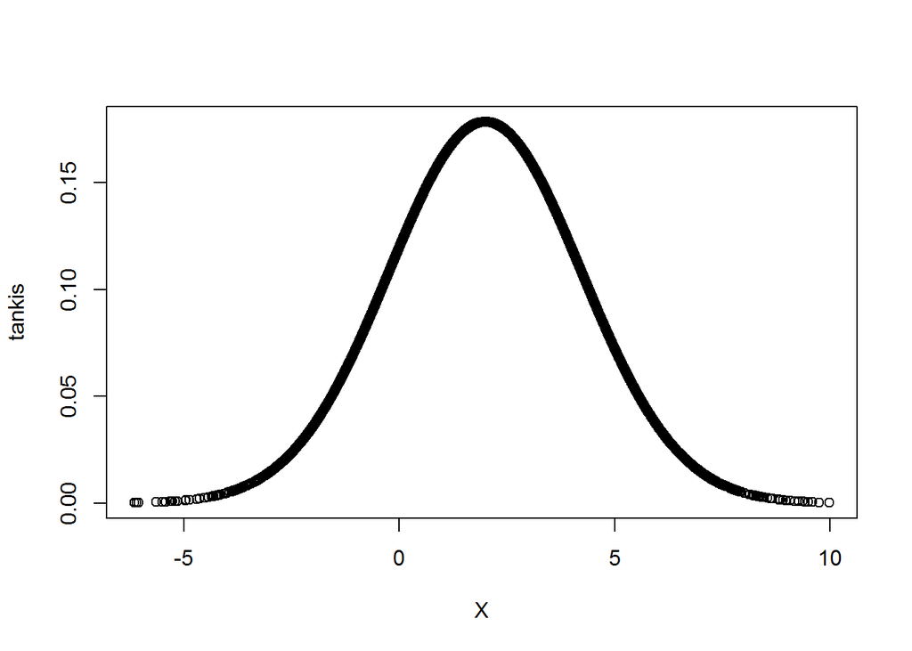

```r
plot(X, dnorm(X, mean = 2, sd = sqrt(5)), xlab = "X", ylab = "tankis")
```

Sugeneruojami atsitiktiniai dydžiai $X_1$ ir $X_2$ su duotais parametrais ir atsitiktinis dydis $X$ kaip jų suma:

```r
X1 = rnorm(10000, mean = 3, sd = sqrt(2))
X2 = rnorm(10000, mean = -1, sd = sqrt(3))
ktX = X1 + X2
```

Palyginimui nubraižomas teorinės ir empirinės tankio funkcijos grafikas:

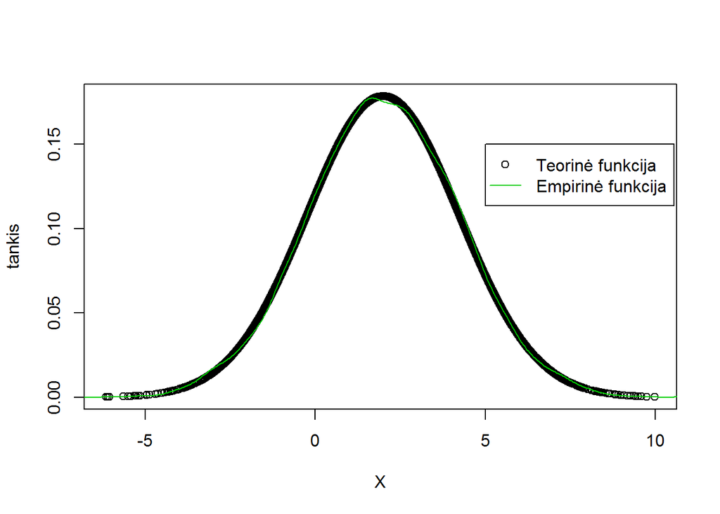

```r
plot(X, dnorm(X, mean = 2, sd = sqrt(5)), xlab = "X", ylab = "tankis" )
lines(density(ktX), col = 3)
legend(5, 0.15, c("Teorinė funkcija", "Empirinė funkcija"), lty = c(0, 1), pch = c(1, NA), col = c(1, 3))
```

Tikrinamos empirinės sklaidos charakteristikos. Vidurkis:

```r
mean(ktX)
```

```
## [1] 2.015447
```

Teorinis vidurkis yra 2. Standartinis nuokrypis:

```r
sd(ktX)
```

```
## [1] 2.215323
```

Teorinis standartinis nuokrypis:

```r
sqrt(5)
```

```
## [1] 2.236068
```

Mediana:

```r
median(ktX)
```

```
## [1] 2.015845
```

Teorinė mediana yra 2, sutampa su vidurkiu. Taigi, empirinės charakteristikos šiek tiek skiriasi. Toliau skaičiuojama teorinė tikimybė įvykio $|X| > 2$:

```r
tik <- pnorm(-2, mean = 2, sd = sqrt(5)) + pnorm(2, mean = 2, sd = sqrt(5), lower.tail = FALSE)
tik
```

```
## [1] 0.5368191
```

Sukuriama funkcija, kuri sugeneruotų atsitiktinį dydį ir suskaičiuotų šią tikimybę empiriniu būdu:

```r
emp.tik <- function(){
  X1 = rnorm(10000, mean = 3, sd = sqrt(2))
  X2 = rnorm(10000, mean = -1, sd = sqrt(3))
  X = X1 + X2
  a = (X > 2) | (X < -2)
  ats = sum(a)/10000
  return(ats)
}
emp.tik()
```

```
## [1] 0.5401
```

Funkcija paleidžiama 10000 kartų ir randamas sugeneruotų tikimybių vidurkis:

```r
b <- replicate(10000, emp.tik())
mean(b)
```

```
## [1] 0.5368019
```

Taigi, empirinė tikimybė panaši į teorinę.

Šaltiniai:

Sum of normally distributed random variables, Wikipedia https://en.wikipedia.org/wiki/Sum_of_normally_distributed_random_variables

Normal distribution, Wikipedia https://en.wikipedia.org/wiki/Normal_distribution

The Normal Distribution, R Documentation https://stat.ethz.ch/R-manual/R-devel/library/stats/html/Normal.html

Cross Validated http://stats.stackexchange.com/questions/237237/what-is-the-difference-between-theoretical-distribution-and-empirical-distributi